# Vignette 01: Setup and Introduction

GAJ

2024-11-25

This vignette will guide you through the setup of the `paRsynth` package, introduce its purpose and functions before demonstrating how to utilize it for your research.

## Install R and RStudio

- To install R on your computer, go to the [R project website](https://www.r-project.org/) and download the latest version of R for your operating system (Windows, macOS, or Linux). Follow the installation instructions provided on the site.
- To install RStudio on your computer, go to the [RStudio website](https://posit.co/download/rstudio-desktop/). RStudio is an integrated development environment (IDE) that makes working with R an accessible and more user-friendly experience. Follow the installation instructions provided on the site.

Check out the introductory lesson [R for Reproducible Scientific Analysis](https://swcarpentry.github.io/r-novice-gapminder/) provided by the [Software Carpentry](https://software-carpentry.org/) if you are new to R and RStudio.

Once you have R and RStudio installed on your computer, you can open RStudio by clicking on the software icon.

## Configure your RStudio session

RStudio displays four panes in your workspace: source, console, environment, and files. You can reconfigure the panes so that the source and console panes are horizontally next to one another. This makes it easier to immediately check the output of any code that you run.

- Go to the tool bar above the R Studio window and select the option “Tools”
- Select “Global Options” in the pop-up menu
- Select the option “Pane Layout” along the left hand side
- Use the dropdown menus to select “Source” as the top right pane and “Console” as the top left pane
- Select “Apply” to apply those changes, then “OK” to exit this window

You can also reconfigure the soft-wrapping lines of text and code. You don’t have to scroll horizontally to see long lines of text in your Source pane.

- Go to the tool bar above the R Studio window and select the option “Tools”
- Select “Global Options” in the pop-up menu
- Select the option “Code” on the left hand side
- Check the box next to the option “Soft-wrap R source files”
- Select “Apply” to apply those changes, then “OK” to exit

You can also change the font size, font color, and background color of your RStudio workspace.

- Go to the tool bar above the R Studio window and select the option “Tools”
- Select “Global Options” in the pop-up menu
- Select the option “Appearance” along the left hand side to see some different options

## Install GitHub

You will need to install GitHub Desktop to later clone the `paRsynth` package on your local machine.

- Go to the [GitHub Desktop website](https://github.com/apps/desktop) and click “Download now” to install GitHub Desktop on your computer
- Open GitHub Desktop by clicking on the software icon after downloaded

## Clone `paRsynth`

- Open the [`paRsynth` GitHub repository](https://github.com/gsvidaurre/paRsynth) on your internet browser
- Click on the arrow of the green “Code” button on the top right
- Click on the copy link icon
- Navigate to the top left toolbar of GitHub Desktop, click on File > Clone Repository
- Paste the URL from the `paRsynth` GitHub repository
- Ensure the “Local Path” is where you want the `paRsynth` repository to be located on your local machine
- Click on the blue “Clone” button
- Check to see that the `paRsynth` package is located in the appropriate local path of your machine that you assigned it to

## Purpose

`paRsynth` uses Parsons code to convert randomly generated character strings to frequency modulated vocalizations with different amounts of individual identity and group membership information. The functions in this package were developed for the sonification of character strings that represent vocal signals with varying amounts of social information. The resulting audio files (created using the soundgen package) can be used in downstream bioacoustics analyses. By using widely accepted bioacoustic analysis tools on these vocalizations, those tools can be evaluated for accuracy on social information detection.

Please read the README.rmd file for more information on the package, code collaborators, code collaboration guidelines and package usage/maintenance. Refer to that file if you have trouble-shooting errors or would like to know how to report a bug on GitHub.

## Functions

`paRsynth` provides four functions for the simulation of vocalizations with representation of both individual identity and group membership information. These vocalizations are encoded as strings that can be used for generating synthetic audio signals for bioacoustic analysis. The next vignette (*Vignette 02: Create Vocal Identity Signals with `paRsynth`*) will demonstrate how to use the package’s functions to generate vocalizations strings, convert them into Parsons code, calculate frequency anchors, and generate synthetic audio files.

1. `generate_strings()`: generates strings that encode group membership information and individual identity information.
2. `parsons_code()`: converts the generated strings (characters) into Parsons code (musical up-down-constant connotation) for frequency modulation.
3. `frequency_anchors()`: calculates frequency anchors (numeric values that correspond to each segment of the Parsons code string) from Parsons code to guide the creation of synthetic audio.
4. `write_audio()`: uses frequency anchors and the ‘soundgen’ package to generate and save synthetic audio files.

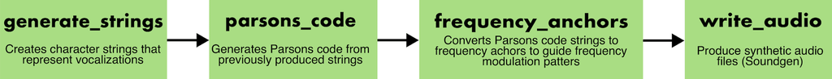

Figure 1. `paRsynth` functions workflow

Navigate to *Vignette 02: Create Vocal Identity Signals with `paRsynth`* to learn how to use the package described above for your projects.